# EDA_tcga

2025-06-09

```r
library(foreign)
library(tidyverse)
```

Reading in tcga data

```r
tcga = read.csv("TCGA-READ_clinical.csv",header = T,stringsAsFactors = F)
#str(tcga)
```

Checking data structure

```r
str(tcga)
```

```
## 'data.frame':    172 obs. of  167 variables:
##  $ project                                             : chr  "TCGA-READ" "TCGA-READ" "TCGA-READ" "TCGA-READ" ...
##  $ submitter_id                                        : chr  "TCGA-AF-3912" "TCGA-AG-4009" "TCGA-G5-6572" "TCGA-AG-3580" ...
##  $ synchronous_malignancy                              : chr  "Not Reported" "No" "No" "No" ...
##  $ ajcc_pathologic_stage                               : chr  NA "Stage I" NA "Stage I" ...
##  $ days_to_diagnosis                                   : int  NA 0 0 0 0 0 0 0 0 0 ...
##  $ created_datetime                                    : chr  "2019-04-28T10:56:20.877264-05:00" NA NA NA ...
##  $ last_known_disease_status                           : chr  "not reported" NA NA NA ...
##  $ tissue_or_organ_of_origin                           : chr  "Rectosigmoid junction" "Rectum, NOS" "Rectosigmoid junction" "Rectosigmoid junction" ...
##  $ age_at_diagnosis                                    : int  NA 30559 20475 24775 24411 27443 24806 22830 23496 22950 ...
##  $ primary_diagnosis                                   : chr  "Adenocarcinoma, NOS" "Adenocarcinoma, NOS" "Adenocarcinoma, NOS" "Adenocarcinoma, NOS" ...
##  $ updated_datetime                                    : chr  "2025-01-08T13:19:11.073020-06:00" "2025-03-26T09:15:20.563867-05:00" "2025-03-26T09:15:20.563867-05:00" "2025-03-26T09:15:20.563867-05:00" ...
##  $ prior_malignancy                                    : chr  "not reported" "no" "no" "no" ...
##  $ year_of_diagnosis                                   : int  NA 2009 2004 2007 2009 2009 2008 2005 2009 2009 ...
##  $ state                                               : chr  "released" "released" "released" "released" ...
```

[output cut: 86 more lines]

Most data types that are not numeric should be categorical. So will convert the characters to categorical

```r
tcga = tcga %>%
  mutate_if(is.character, as.factor)

str(tcga)
```

```
## 'data.frame':    172 obs. of  167 variables:
##  $ project                                             : Factor w/ 1 level "TCGA-READ": 1 1 1 1 1 1 1 1 1 1 ...
##  $ submitter_id                                        : Factor w/ 172 levels "TCGA-AF-2687",..: 9 73 171 23 58 6 66 92 84 57 ...
##  $ synchronous_malignancy                              : Factor w/ 3 levels "No","Not Reported",..: 2 1 1 1 1 1 1 1 1 1 ...
##  $ ajcc_pathologic_stage                               : Factor w/ 11 levels "Stage I","Stage II",..: NA 1 NA 1 1 1 1 10 1 1 ...
##  $ days_to_diagnosis                                   : int  NA 0 0 0 0 0 0 0 0 0 ...
##  $ created_datetime                                    : Factor w/ 2 levels "2019-04-28T10:56:20.877264-05:00",..: 1 NA NA NA NA NA NA NA NA NA ...
##  $ last_known_disease_status                           : Factor w/ 1 level "not reported": 1 NA NA NA NA NA NA NA NA NA ...
##  $ tissue_or_organ_of_origin                           : Factor w/ 6 levels "Colon, NOS","Connective, subcutaneous and other soft tissues of abdomen",..: 4 5 4 4 5 4 4 5 5 5 ...
##  $ age_at_diagnosis                                    : int  NA 30559 20475 24775 24411 27443 24806 22830 23496 22950 ...
##  $ primary_diagnosis                                   : Factor w/ 6 levels "Adenocarcinoma in tubulovillous adenoma",..: 3 3 3 3 3 3 3 3 3 3 ...
##  $ updated_datetime                                    : Factor w/ 2 levels "2025-01-08T13:19:11.073020-06:00",..: 1 2 2 2 2 2 2 2 2 2 ...
##  $ prior_malignancy                                    : Factor w/ 3 levels "no","not reported",..: 2 1 1 1 1 1 1 3 3 1 ...
##  $ year_of_diagnosis                                   : int  NA 2009 2004 2007 2009 2009 2008 2005 2009 2009 ...
##  $ state                                               : Factor w/ 1 level "released": 1 1 1 1 1 1 1 1 1 1 ...
```

[output cut: 86 more lines]

```r
na_count = apply(tcga,2,function(x){sum(is.na(x))})
na_count_o = sort(na_count,decreasing = TRUE)
na_count_o[1:10]
```

```
##    days_to_last_known_disease_status                   days_to_recurrence
##                                  172                                  172
##                      tumor_of_origin                            irs_stage
##                                  172                                  172
##                            iss_stage             ann_arbor_clinical_stage
##                                  172                                  172
##                  enneking_msts_stage                           inrg_stage
##                                  172                                  172
##             enneking_msts_metastasis esophageal_columnar_dysplasia_degree
##                                  172                                  172
```

```r
varibles_half_na = names(na_count_o)[na_count_o >= max(na_count_o)/2]
`%ni%` = Negate(`%in%`)
tcga_use = tcga[,colnames(tcga) %ni% varibles_half_na]
```

Using mice for missing data analysis among remaining variables

```r
library(mice)
library(VIM)
```

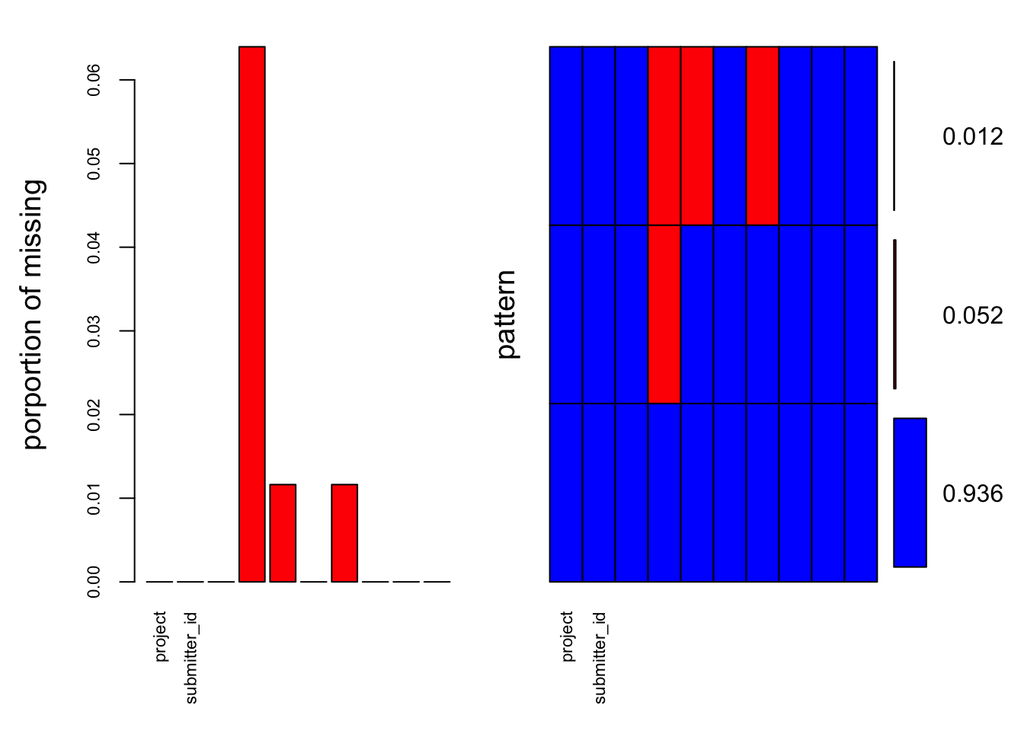

```r
## red is missing and blue is not missing
missing_val_plot = aggr(tcga_use[,c(1:10)], col=c("blue","red"),
                   numbers=TRUE,sortVard=TRUE,
                     labels = names(tcga_use),cex.axis=.7,
                       gap=3,ylab=c("porportion of missing","pattern"))
```

```r
#md.pattern(tcga_use,rotate.names = TRUE)
```

Display missing-data patterns

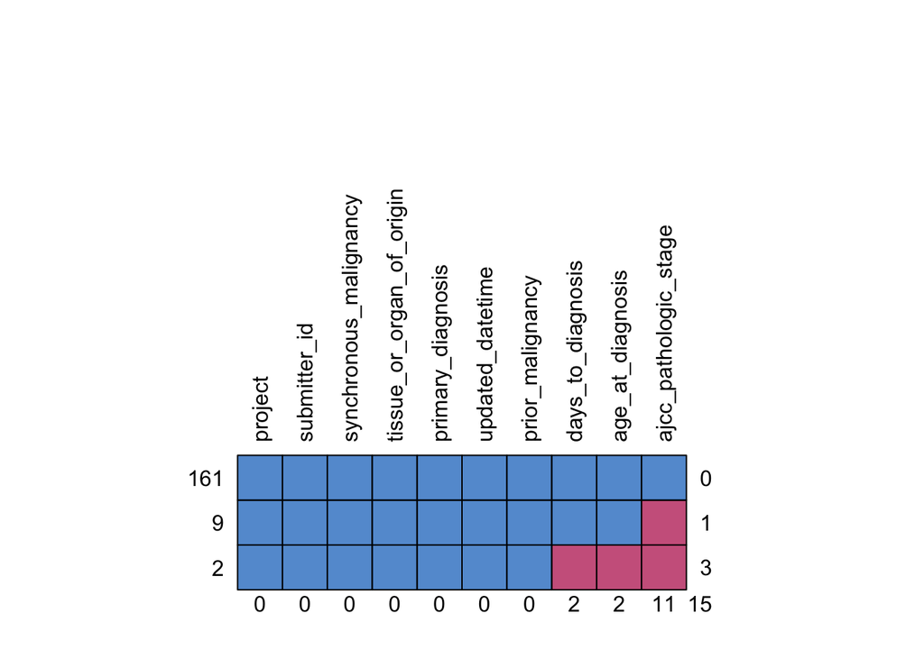

```
##     project submitter_id synchronous_malignancy tissue_or_organ_of_origin
## 161       1            1                      1                         1
## 9         1            1                      1                         1
## 2         1            1                      1                         1
##           0            0                      0                         0
##     primary_diagnosis updated_datetime prior_malignancy days_to_diagnosis
## 161                 1                1                1                 1
## 9                   1                1                1                 1
## 2                   1                1                1                 0
##                     0                0                0                 2
##     age_at_diagnosis ajcc_pathologic_stage
## 161                1                     1  0
## 9                  1                     0  1
## 2                  0                     0  3
##                    2                    11 15
```

```r
md.pattern(tcga_use[,c(1:10)],rotate.names = TRUE) ## difficul tot understand
```

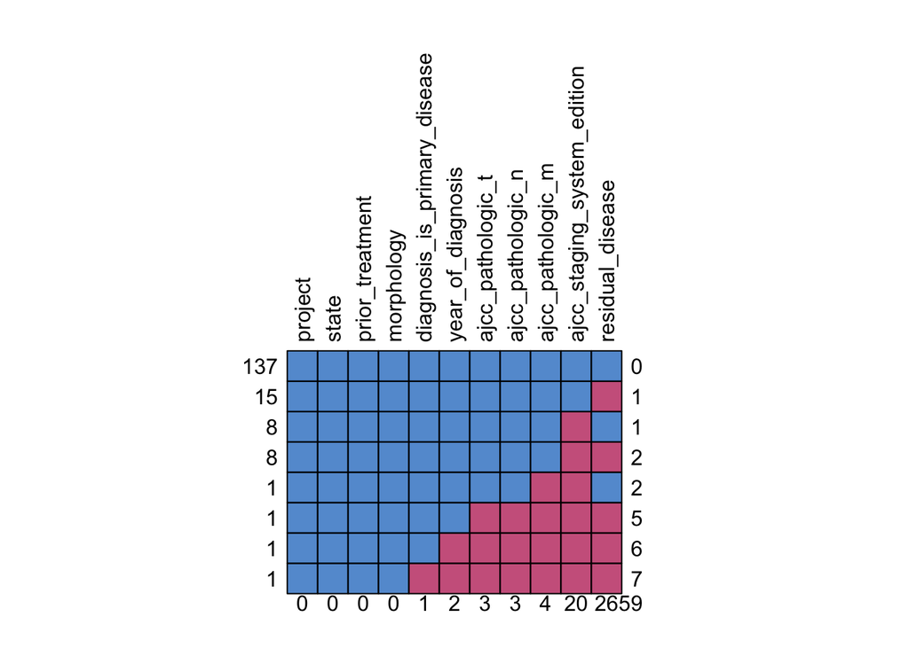

```
##     project state prior_treatment morphology diagnosis_is_primary_disease
## 137       1     1               1          1                            1
## 15        1     1               1          1                            1
## 8         1     1               1          1                            1
## 8         1     1               1          1                            1
## 1         1     1               1          1                            1
## 1         1     1               1          1                            1
## 1         1     1               1          1                            1
## 1         1     1               1          1                            0
##           0     0               0          0                            1
##     year_of_diagnosis ajcc_pathologic_t ajcc_pathologic_n ajcc_pathologic_m
## 137                 1                 1                 1                 1
## 15                  1                 1                 1                 1
## 8                   1                 1                 1                 1
## 8                   1                 1                 1                 1
## 1                   1                 1                 1                 0
## 1                   1                 0                 0                 0
## 1                   0                 0                 0                 0
## 1                   0                 0                 0                 0
##                     2                 3                 3                 4
##     ajcc_staging_system_edition residual_disease
## 137                           1                1  0
## 15                            1                0  1
## 8                             0                1  1
## 8                             0                0  2
## 1                             0                1  2
## 1                             0                0  5
## 1                             0                0  6
## 1                             0                0  7
##                              20               26 59
```

```r
md.pattern(tcga_use[,c(1,11:20)],rotate.names = TRUE)
```

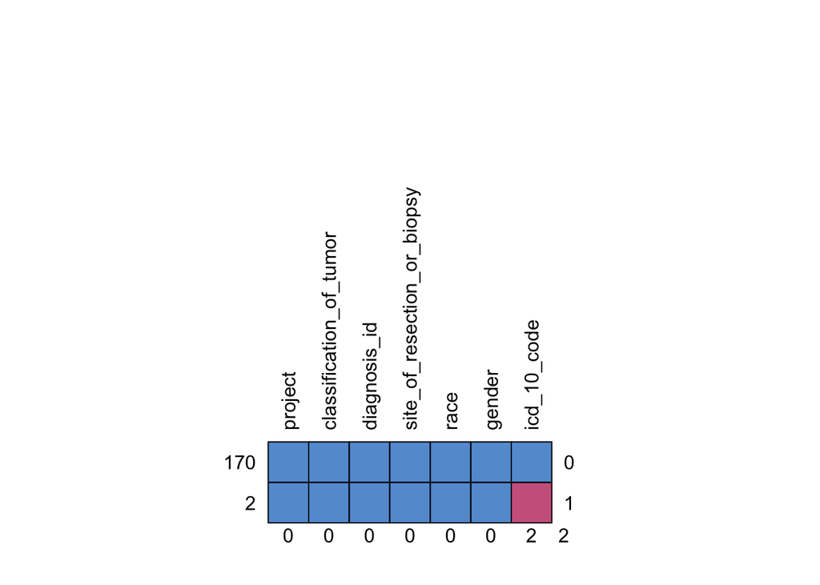

```
##     project classification_of_tumor diagnosis_id site_of_resection_or_biopsy
## 170       1                       1            1                           1
## 2         1                       1            1                           1
##           0                       0            0                           0
##     race gender icd_10_code
## 170    1      1           1 0
## 2      1      1           0 1
##        0      0           2 2
```

```r
md.pattern(tcga_use[,c(1,21:26)],rotate.names = TRUE)
```

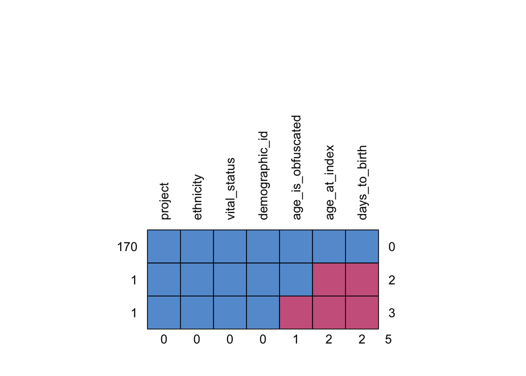

```
##     project ethnicity vital_status demographic_id age_is_obfuscated
## 170       1         1            1              1                 1
## 1         1         1            1              1                 1
## 1         1         1            1              1                 0
##           0         0            0              0                 1
##     age_at_index days_to_birth
## 170            1             1 0
## 1              0             0 2
## 1              0             0 3
##                2             2 5
```

```r
md.pattern(tcga_use[,c(1,27:32)],rotate.names = TRUE)
```

[figure not shown]

[output not shown]

[output cut: 76 more lines]

```r
md.pattern(tcga_use[,c(1,33:42)],rotate.names = TRUE)
```

What could be some of the most interesting clinical variables? tissue_or_organ_of_origin - Rectum, NOS or Rectosigmoid junction primary_diagnosis - Adenocarcinoma, NOS, ajcc_pathologic_t ajcc_pathologic_m residual_disease site_of_resection_or_biopsy race gender ethnicity vital_status

Majority of the Adenocarcinoma, NOS are ones are either Rectosigmoid junction or Rectum, NOS. Compare Most of the Rectosigmoid junction and reactum NOS are T3 in ajcc_pathologic_t Most of the Rectosigmoid junction and reactum NOS are M0 in ajcc_pathologic_m

```r
count_by_race_tissue_origin=tcga_use %>%
  group_by(tissue_or_organ_of_origin, race) %>%
  summarise(n= n())
chisq.test(count_by_race_tissue_origin$race,count_by_race_tissue_origin$tissue_or_organ_of_origin)## No asso
```

```
##
##  Pearson's Chi-squared test
##
## data:  count_by_race_tissue_origin$race and count_by_race_tissue_origin$tissue_or_organ_of_origin
## X-squared = 8.6472, df = 15, p-value = 0.8952
```

```r
count_by_gender_tissue_origin=tcga_use %>%
  group_by(tissue_or_organ_of_origin, gender) %>%
  summarise(n= n())
chisq.test(count_by_gender_tissue_origin$gender,count_by_gender_tissue_origin$tissue_or_organ_of_origin)## No asso
```

```
##
##  Pearson's Chi-squared test
##
## data:  count_by_gender_tissue_origin$gender and count_by_gender_tissue_origin$tissue_or_organ_of_origin
## X-squared = 8.3333, df = 10, p-value = 0.5963
```

How is vital status affected by tumor grading or biopsy?

```r
vital_status_by_ajcc_t = tcga_use %>%
  group_by(vital_status,ajcc_pathologic_t) %>%
  summarise(n = n())
chisq.test(vital_status_by_ajcc_t$vital_status,vital_status_by_ajcc_t$ajcc_pathologic_t)## No asso
```

```
##
##  Pearson's Chi-squared test
##
## data:  vital_status_by_ajcc_t$vital_status and vital_status_by_ajcc_t$ajcc_pathologic_t
## X-squared = 2, df = 5, p-value = 0.8491
```

```r
vital_status_by_ajcc_m = tcga_use %>%
  group_by(vital_status,ajcc_pathologic_m) %>%
  summarise(n = n())
chisq.test(vital_status_by_ajcc_m$vital_status,vital_status_by_ajcc_m$ajcc_pathologic_m)## No asso
```

```
##
##  Pearson's Chi-squared test
##
## data:  vital_status_by_ajcc_m$vital_status and vital_status_by_ajcc_m$ajcc_pathologic_m
## X-squared = 0.875, df = 3, p-value = 0.8315
```

```r
vital_status_by_site_rejection_biopsy = tcga_use %>%
  group_by(vital_status,site_of_resection_or_biopsy) %>%
  summarise(n = n())
chisq.test(vital_status_by_site_rejection_biopsy$vital_status,vital_status_by_site_rejection_biopsy$site_of_resection_or_biopsy)## No asso
```

```
##
##  Pearson's Chi-squared test
##
## data:  vital_status_by_site_rejection_biopsy$vital_status and vital_status_by_site_rejection_biopsy$site_of_resection_or_biopsy
## X-squared = 1.6667, df = 6, p-value = 0.9477
```

```r
vital_status_by_primary_diagnosis = tcga_use %>%
  group_by(vital_status,primary_diagnosis) %>%
  summarise(n = n())
chisq.test(vital_status_by_primary_diagnosis$vital_status,vital_status_by_primary_diagnosis$primary_diagnosis)## No asso
```

```
##
##  Pearson's Chi-squared test
##
## data:  vital_status_by_primary_diagnosis$vital_status and vital_status_by_primary_diagnosis$primary_diagnosis
## X-squared = 7.65, df = 10, p-value = 0.663
```

Does missingness of important variables associate with outcome?

```r
missing_ajcc_t <- as.factor(is.na(tcga_use$ajcc_pathologic_t))

table(tcga_use$vital_status,missing_ajcc_t)
```

```
##               missing_ajcc_t
##                FALSE TRUE
##   Alive          142    0
##   Dead            27    1
##   Not Reported     0    2
```

```r
fisher.test(tcga_use$vital_status,missing_ajcc_t)## Significant
```

```
##
##  Fisher's Exact Test for Count Data
##
## data:  tcga_use$vital_status and missing_ajcc_t
## p-value = 3.36e-05
## alternative hypothesis: two.sided
```

```r
missing_ajcc_m <- as.factor(is.na(tcga_use$ajcc_pathologic_m))

table(tcga_use$vital_status,missing_ajcc_m)
```

```
##               missing_ajcc_m
##                FALSE TRUE
##   Alive          141    1
##   Dead            27    1
##   Not Reported     0    2
```

```r
fisher.test(tcga_use$vital_status,missing_ajcc_m)## Significant
```

```
##
##  Fisher's Exact Test for Count Data
##
## data:  tcga_use$vital_status and missing_ajcc_m
## p-value = 0.0001237
## alternative hypothesis: two.sided
```

```r
missing_site_resection_biopsy <- as.factor(is.na(tcga_use$site_of_resection_or_biopsy))

table(tcga_use$vital_status,missing_site_resection_biopsy)
```

```
##               missing_site_resection_biopsy
##                FALSE
##   Alive          142
##   Dead            28
##   Not Reported     2
```

```r
#fisher.test(tcga_use$vital_status,missing_site_resection_biopsy)## one level in missing_site_resection_biopsy
```

Reading in gene expression data

```r
gene_exp = read.table(file="TCGA-READ_RNASeq_count_Data.txt",header = T,sep="\t",stringsAsFactors = F)

sample_ids = colnames(gene_exp)
```

Cleaning_up_the_sample_IDs

```r
sample_ids_edited=str_replace_all(sample_ids,"\\.","_")
colnames(gene_exp) = sample_ids_edited

tcga_use$bcr_patient_barcode_mod = str_replace_all(tcga_use$bcr_patient_barcode,"-","_")
```

Now, going to take the order of the samples of the gene exp matrix and order the metadata in the same order

```r
gene_exp_ids = colnames(gene_exp)

gene_exp_ids = as.data.frame(gene_exp_ids)

library(stringr)
gene_exp_ids <- str_split_fixed(gene_exp_ids$gene_exp_ids, '_',7)
gene_exp_ids = as.data.frame(gene_exp_ids)
gene_exp_ids$New_RNA_id=paste(gene_exp_ids$V1,gene_exp_ids$V2,gene_exp_ids$V3,sep="_")

length(intersect(gene_exp_ids$New_RNA_id,tcga_use$bcr_patient_barcode_mod)) ## 167
```

```
## [1] 167
```

```r
gene_exp_ids$Original_ID = colnames(gene_exp)


colnames(gene_exp_ids)[1:7]=c("Project","TSS","Participant","Sample_Vial","Portion_Analyte","Plate","Center")
```

Going ot restrict the analysis to only tumor samples of vial A by filtering on the 4th field of the name whereby 01-09 for tumor and 10-19 are normal

```r
table(gene_exp_ids$Sample)
```

```
##
## 01A 01B 01C 02A 11A
## 163   2   1   1  10
```

```r
samples_use = subset(gene_exp_ids,gene_exp_ids$Sample_Vial=="01A")
```

Now going to use the order of the samples_use df to order the samples and extract the gene expression matrix for corresponding_Samples

```r
samples_use_clinical = left_join(samples_use,tcga_use,by=c("New_RNA_id"="bcr_patient_barcode_mod"))

gene_exp_use = gene_exp[,samples_use_clinical$Original_ID]
```

Some variables have to still be converted to factor for the model

```r
samples_use_clinical$Portion_Analyte = as.factor(samples_use_clinical$Portion_Analyte)

samples_use_clinical$age_diag_c = scale(samples_use_clinical$age_at_diagnosis,center = TRUE)
```

Now checking to see which of the adjusting variables have a lot of NA. Will drop it.

```r
NA_count = apply(samples_use_clinical,2,function(x){sum(is.na(x))})
NA_count
```

```
##                                       Project
##                                             0
##                                           TSS
##                                             0
##                                   Participant
##                                             0
##                                   Sample_Vial
##                                             0
##                               Portion_Analyte
##                                             0
##                                         Plate
##                                             0
##                                        Center
##                                             0
##                                    New_RNA_id
##                                             0
##                                   Original_ID
##                                             0
##                                       project
##                                             0
##                                  submitter_id
##                                             0
##                        synchronous_malignancy
##                                             0
##                         ajcc_pathologic_stage
##                                            10
##                             days_to_diagnosis
##                                             1
##                     tissue_or_organ_of_origin
##                                             0
##                              age_at_diagnosis
##                                             1
##                             primary_diagnosis
##                                             0
##                              updated_datetime
##                                             0
##                              prior_malignancy
##                                             0
##                             year_of_diagnosis
##                                             1
```

[output cut: 49 more lines]

```
##                                            24
##           treatments_radiation_treatment_type
##                                            24
##     treatments_radiation_treatment_or_therapy
##                                            24
##    treatments_radiation_treatment_intent_type
##                                            42
##  treatments_radiation_route_of_administration
##                                            24
## treatments_radiation_treatment_anatomic_sites
##                                            24
##                           bcr_patient_barcode
##                                             0
##                                    age_diag_c
##                                             1
```

```r
samples_use_clinical_final = samples_use_clinical[,c("Original_ID",
  "vital_status","ajcc_pathologic_t","ajcc_pathologic_m","gender","age_diag_c","race","ethnicity","Portion_Analyte")]
samples_use_clinical_final = samples_use_clinical_final[complete.cases(samples_use_clinical_final),]

gene_exp_use = gene_exp[,samples_use_clinical_final$Original_ID]
```

Checking that the order of the samples in gene exp matrix and metdata are the same

```r
table(samples_use_clinical_final$Original_ID == colnames(gene_exp_use))
```

```
##
## TRUE
##  160
```

Now carrying out DE analysis using DESeq2

```r
library(DESeq2)
library(edgeR)
dds = DESeqDataSetFromMatrix(gene_exp_use,colData = samples_use_clinical_final,
                             design = ~ vital_status + ajcc_pathologic_t + ajcc_pathologic_m + gender + age_diag_c + race + ethnicity + Portion_Analyte)
```

```
## factor levels were dropped which had no samples
```

```
##   Note: levels of factors in the design contain characters other than
##   letters, numbers, '_' and '.'. It is recommended (but not required) to use
##   only letters, numbers, and delimiters '_' or '.', as these are safe characters
##   for column names in R. [This is a message, not a warning or an error]
```

```r
keep = rowSums( cpm(dds) >2) >= 5 ## dds >2 in at least 5 of sequenced sampels

table(keep)
```

```
## keep
## FALSE  TRUE
## 43116 17544
```

```r
dds = dds[keep,]
```

```r
ntd <- normTransform(dds)
```

[output not shown]

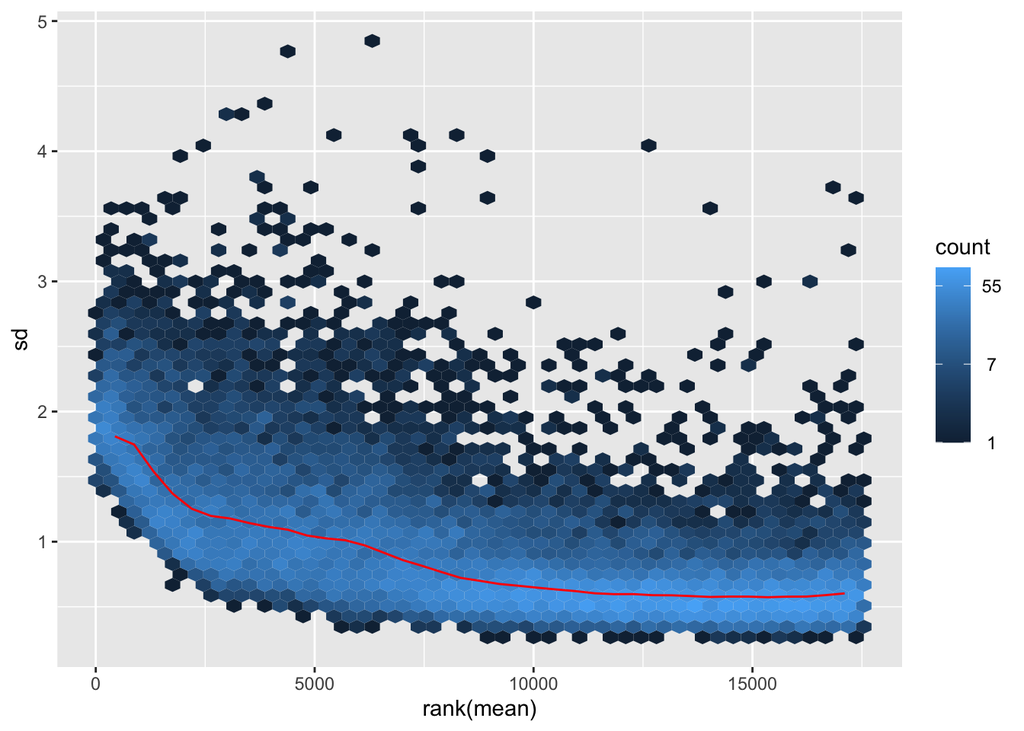

```r
library("vsn")
meanSdPlot(assay(ntd))
```

```r
vsd <- vst(dds, blind = FALSE)
```

[output not shown]

```r
dds <- estimateSizeFactors(dds)
```

[output not shown]

Now estimating the size factor and generating the PCA plots

```
## using ntop=500 top features by variance
```

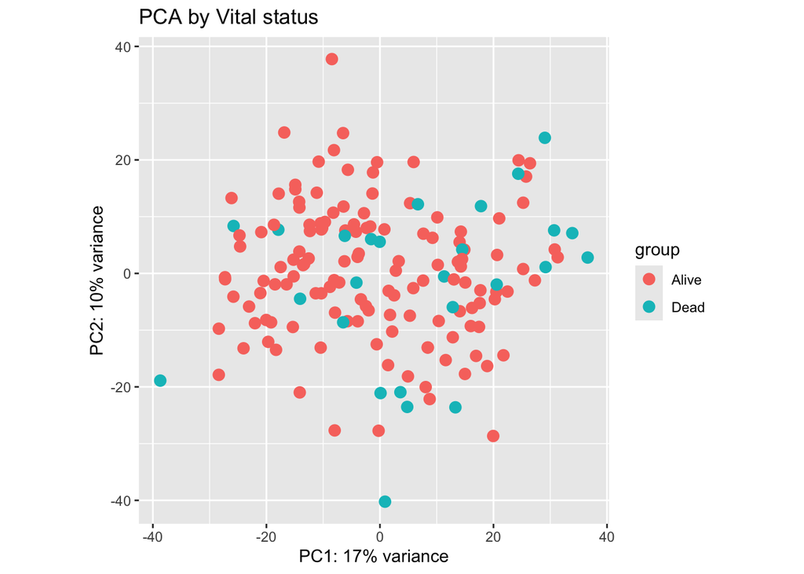

```r
plotPCA(vsd, intgroup = c("vital_status")) +ggtitle("PCA by Vital status")
```

```
## using ntop=500 top features by variance
```

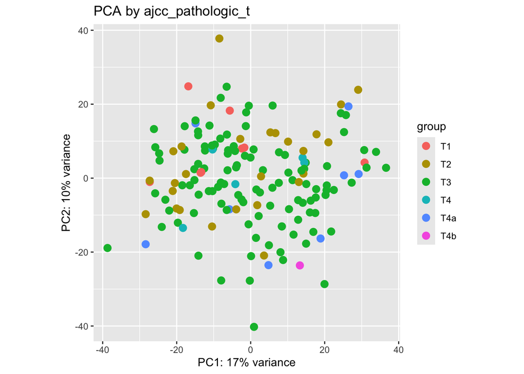

```r
plotPCA(vsd, intgroup = c("ajcc_pathologic_t")) +ggtitle("PCA by ajcc_pathologic_t")
```

```
## using ntop=500 top features by variance
```

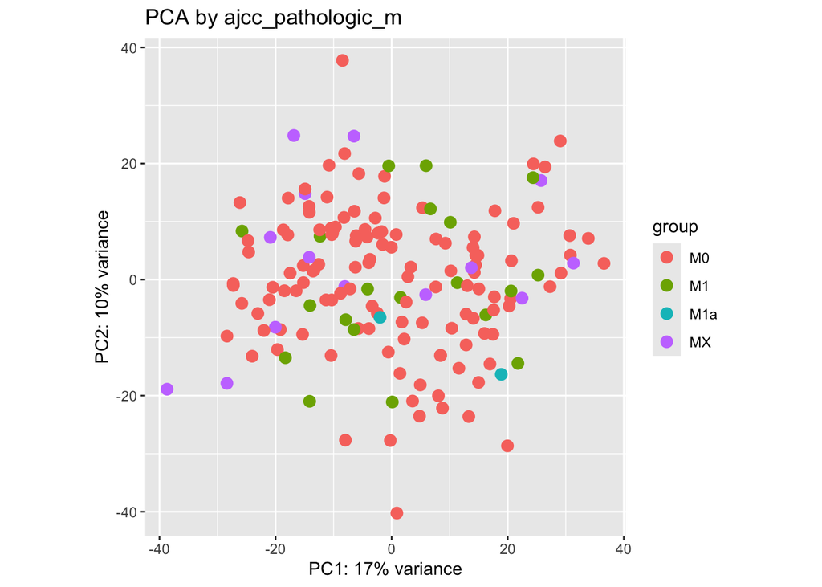

```r
plotPCA(vsd, intgroup = c("ajcc_pathologic_m")) +ggtitle("PCA by ajcc_pathologic_m")
```

```
## using ntop=500 top features by variance
```

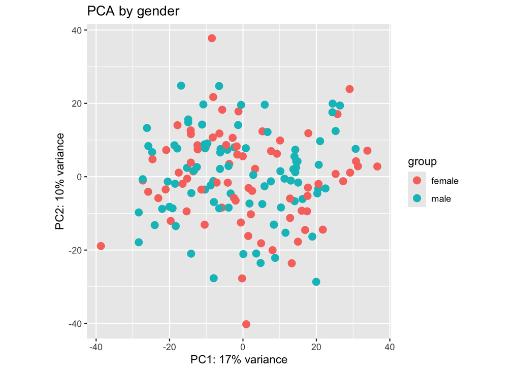

```r
plotPCA(vsd, intgroup = c("gender")) +ggtitle("PCA by gender")
```

```
## using ntop=500 top features by variance
```

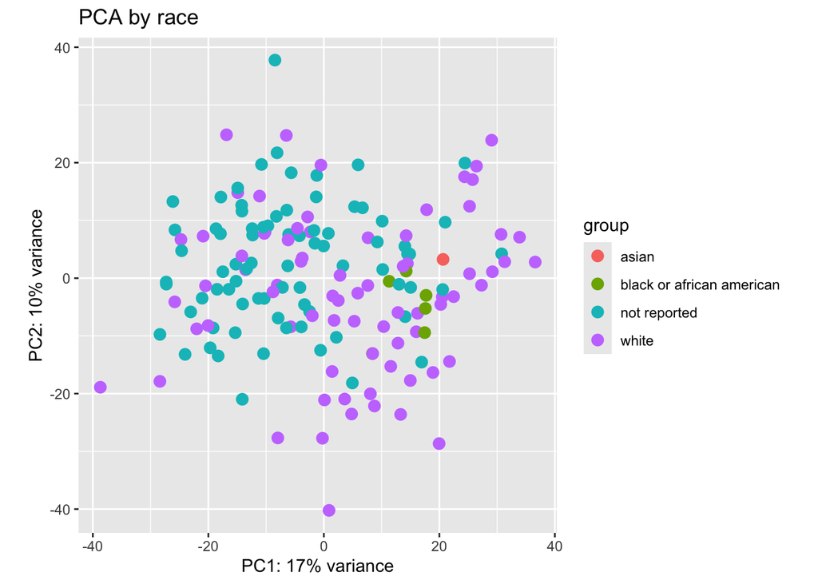

```r
plotPCA(vsd, intgroup = c("race")) +ggtitle("PCA by race")
```

```
## using ntop=500 top features by variance
```

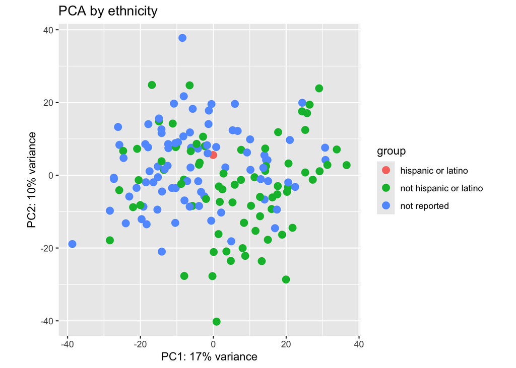

```r
plotPCA(vsd, intgroup = c("ethnicity")) +ggtitle("PCA by ethnicity")
```

```
## using ntop=500 top features by variance
```

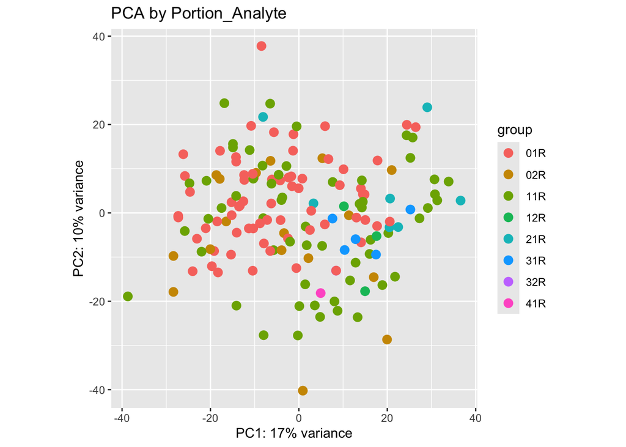

```r
plotPCA(vsd, intgroup = c("Portion_Analyte")) +ggtitle("PCA by Portion_Analyte")
```

```r
design(dds) = ~ vital_status + ajcc_pathologic_t + ajcc_pathologic_m + gender + age_diag_c + race + ethnicity + Portion_Analyte
```

[output not shown]

```r
dds <- DESeq(dds)
```

[output not shown]

```
## 482 rows did not converge in beta, labelled in mcols(object)$betaConv. Use larger maxit argument with nbinomWaldTest
```

```r
#plotMDS(dds)
```

Comparing gene expression pattern by vital_status

```r
res_by_vital_status <- results(dds, contrast=c("vital_status","Dead","Alive"),pAdjustMethod = "BH",format = "DataFrame",cooksCutoff = FALSE)
res_by_vital_status_df=as.data.frame(res_by_vital_status)
res_by_vital_status_df$Ensembl=rownames(res_by_vital_status_df)
summary(res_by_vital_status)
```

```
##
## out of 17544 with nonzero total read count
## adjusted p-value < 0.1
## LFC > 0 (up)       : 117, 0.67%
## LFC < 0 (down)     : 39, 0.22%
## outliers [1]       : 0, 0%
## low counts [2]     : 0, 0%
## (mean count < 5)
## [1] see 'cooksCutoff' argument of ?results
## [2] see 'independentFiltering' argument of ?results
```

```r
res_by_vital_status_df=res_by_vital_status_df[!is.na(res_by_vital_status_df$padj),]
```

Now annotating the genes

```r
library(stringr)
res_by_vital_status_df[c('Ensembl', 'Dot')] <- str_split_fixed(res_by_vital_status_df$Ensembl, '\\.', 2)

library(org.Hs.eg.db)
```

```r
res_by_vital_status_df$Entrez <- mapIds(org.Hs.eg.db, res_by_vital_status_df$Ensembl,keytype="ENSEMBL", column="ENTREZID")
res_by_vital_status_df$Symbol <- mapIds(org.Hs.eg.db, res_by_vital_status_df$Entrez,keytype="ENTREZID", column="SYMBOL")
res_by_vital_status_df$Genename <- mapIds(org.Hs.eg.db, res_by_vital_status_df$Entrez,keytype="ENTREZID", column="GENENAME")
res_by_vital_status_df$Entrez=as.character(res_by_vital_status_df$Entrez)
res_by_vital_status_df$Symbol=as.character(res_by_vital_status_df$Symbol)
res_by_vital_status_df$Genename=as.character(res_by_vital_status_df$Genename)
```

Now generating a summary volcano plot

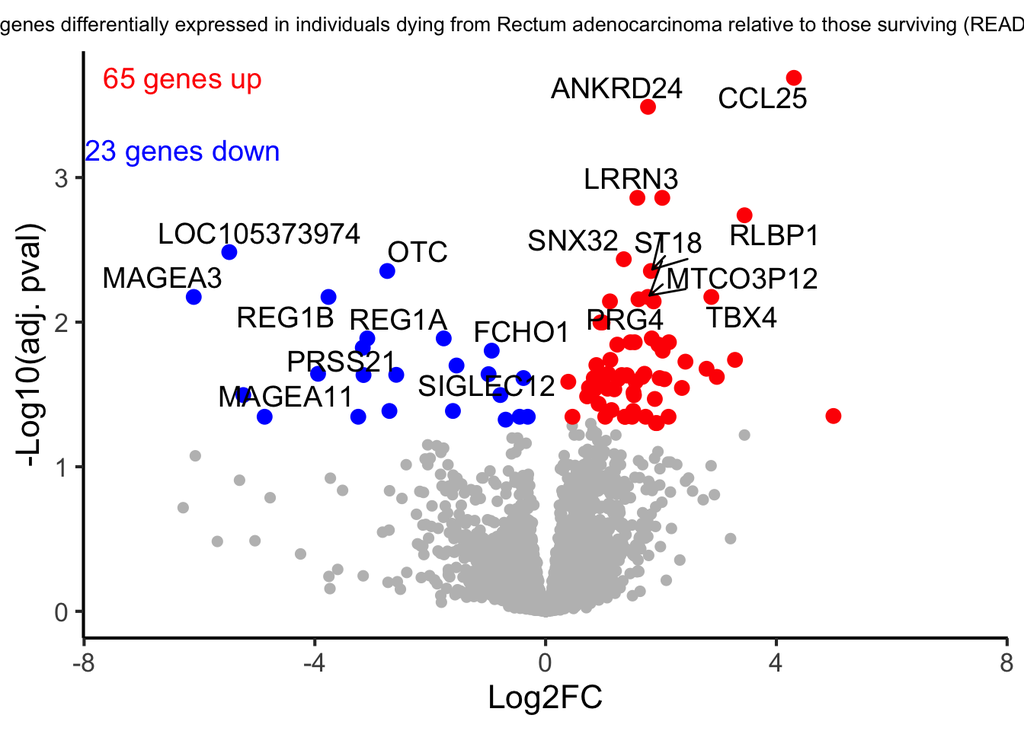

```r
library(ggrepel)
res_by_vital_status_df$Log10_p_val = -log10(res_by_vital_status_df$padj)

upreg = subset(res_by_vital_status_df,res_by_vital_status_df$log2FoldChange > 0 & res_by_vital_status_df$padj < 0.05)

downreg = subset(res_by_vital_status_df,res_by_vital_status_df$log2FoldChange < 0 & res_by_vital_status_df$padj < 0.05)

upreg_o = upreg[order(- upreg$Log10_p_val),]
downreg_o = downreg[order(- downreg$Log10_p_val),]

up_10=upreg_o[1:10,]
dn_10=downreg_o[1:10,]

up_dn_10 = rbind(up_10,dn_10)

up_dn_10_no_NULL = subset(up_dn_10,up_dn_10$Symbol!="NULL")

max_abs_val = max(abs(res_by_vital_status_df$log2FoldChange))

p=ggplot(res_by_vital_status_df, aes(log2FoldChange, Log10_p_val)) +
  theme_classic(base_size = 16)+
  geom_point(data=res_by_vital_status_df, aes(x=log2FoldChange, y=Log10_p_val), colour="grey", size=2)
p1 <- p +  geom_point(data = upreg_o, aes(x=log2FoldChange, y=Log10_p_val) ,size=3,color="red1")
p2 <- p1 +  geom_point(data = downreg_o, aes(x=log2FoldChange, y=Log10_p_val) ,size=3,color="blue1")
p3=p2+ggtitle(paste("Volcano plot for genes differentially expressed in individuals dying from Rectum adenocarcinoma relative to those surviving (READ) (Total genes=",nrow(res_by_vital_status_df),")"))+theme(plot.title = element_text(hjust = 0.5))+theme(plot.title = element_text(hjust = 0.5,size = 10))+annotate(geom="text", x=- max_abs_val, y=max(res_by_vital_status_df$Log10_p_val), label=paste(nrow(upreg_o),"genes up",sep=" "),color="red1",size=5)+annotate(geom="text", x=- max_abs_val  , y=max(max(res_by_vital_status_df$Log10_p_val))-0.5, label=paste(nrow(downreg_o),"genes down",sep=" "),color="blue1",size=5)+xlab("Log2FC")+ylim(0,max(res_by_vital_status_df$Log10_p_val))+xlim(-max_abs_val-1,max_abs_val + 1)+ylab("-Log10(adj. pval)")+geom_text_repel(data=up_dn_10_no_NULL,aes(x=log2FoldChange, y=Log10_p_val,label=Symbol),color="black",arrow=arrow(ends="last",type="open"),size=5,max.overlaps = Inf)
p3
```

Generating aranging the genes in order to generate a Z score heatmap to show that expression data supports logFC data for the DE genes

```r
cpm_ob = cpm(dds)
deg_order = rbind(upreg,downreg)
deg_no_null = subset(deg_order,deg_order$Symbol!="NULL")


cpm_diff_exp_genes = cpm_ob[rownames(deg_no_null),]
rownames(cpm_diff_exp_genes) = deg_no_null$Symbol

cpm_diff_exp_genes_dead = cpm_diff_exp_genes[,samples_use_clinical_final$Original_ID[samples_use_clinical_final$vital_status=="Dead"]]
cpm_diff_exp_genes_alive = cpm_diff_exp_genes[,samples_use_clinical_final$Original_ID[samples_use_clinical_final$vital_status=="Alive"]]
cpm_diff_exp_genes_alive_dead=cbind(cpm_diff_exp_genes_alive,cpm_diff_exp_genes_dead)


alive_samp=subset(samples_use_clinical_final,samples_use_clinical_final$vital_status=="Alive")
dead_samp=subset(samples_use_clinical_final,samples_use_clinical_final$vital_status=="Dead")
alive_Dead_samp = rbind(alive_samp,dead_samp)
rownames(alive_Dead_samp)=alive_Dead_samp$Original_ID

length(intersect(colnames(cpm_diff_exp_genes_alive_dead),rownames(alive_Dead_samp)))
```

```
## [1] 160
```

Actual generation of the Z score heatmap for differentially expressed genes

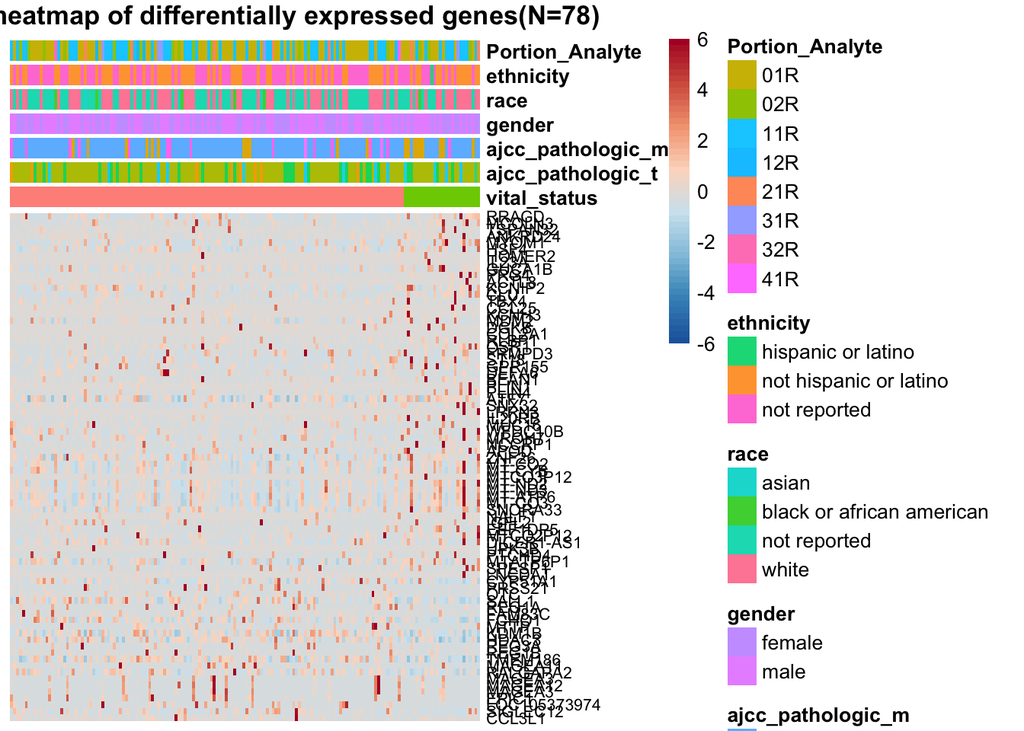

```r
#stage_race_eth=stage_1_4_samp[,c("tumor_stage","race","ethnicity")]
#rownames(stage_race_eth) = rownames(stage_1_4_samp)
#colnames(stage_race_eth)=c("Tumor Stage","Race","Ethnicity")


library(pheatmap)
library(RColorBrewer)
pheatmap_object=pheatmap(cpm_diff_exp_genes_alive_dead,scale = "row",show_rownames = TRUE,cluster_rows = FALSE,fontsize_col=10,annotation_col = alive_Dead_samp[,-c(1,6)],fontsize_row = 8,cluster_cols = FALSE,show_colnames = FALSE,
                         col = colorRampPalette(rev(brewer.pal(8, "RdBu")))(50),breaks = seq(-6, 6, length.out = 51),main=(paste("Z score heatmap of differentially expressed genes(N=",nrow(cpm_diff_exp_genes_alive_dead),")",sep="")))
```

Enrichment analysis using GO or Reactome database to find what functions are the DE genes involved in.

```r
library(clusterProfiler)
library(msigdbr)
library(org.Mm.eg.db)
library(magrittr)
```

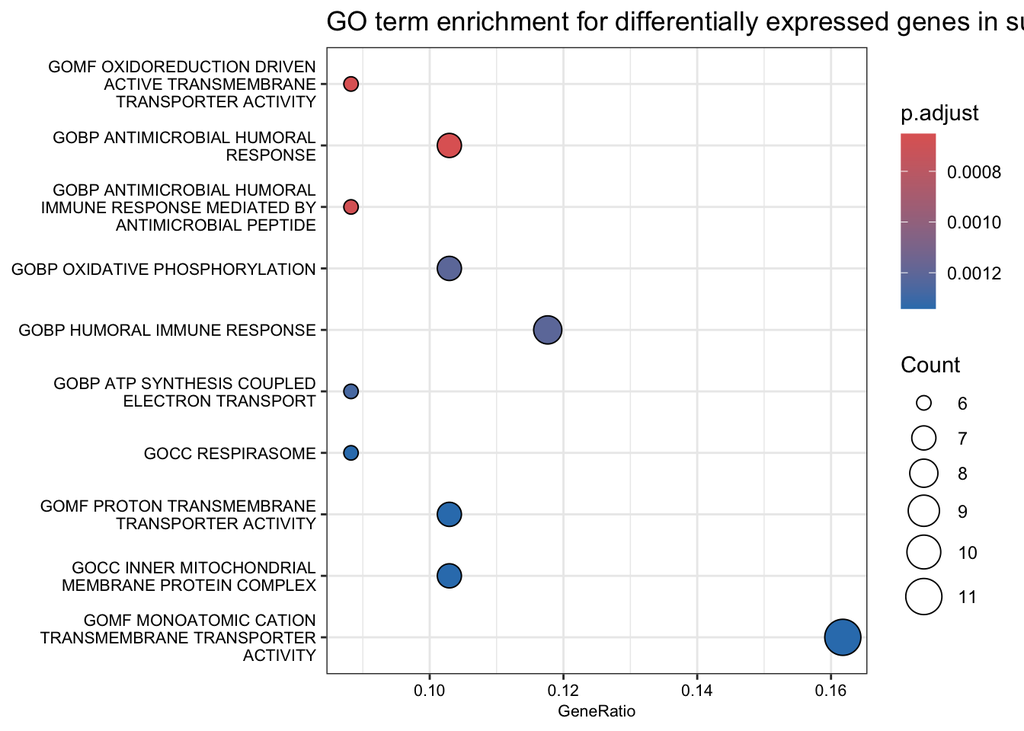

```r
mm_msigdb_df <- msigdbr(species = "Homo sapiens")

mm_GO_df <- mm_msigdb_df %>%
  dplyr::filter(
    gs_collection == "C5", # This is to filter only to the C2 curated gene sets
    gs_subcollection %in% c("GO:BP","GO:CC","GO:MF") # This is because we only want KEGG pathways
  )


mm_Reactome_df <- mm_msigdb_df %>%
  dplyr::filter(
    gs_subcollection == "CP:REACTOME" # This is to filter only to the C2 curated gene sets
     # This is because we only want KEGG pathways
  )


GO_ora_results <- enricher(
  gene = deg_order$Ensembl, # A vector of your genes of interest
  pvalueCutoff = 0.05, # Can choose a FDR cutoff
  pAdjustMethod = "BH",
  universe = res_by_vital_status_df$Ensembl,# Method to be used for multiple testing correction
  # The pathway information should be a data frame with a term name or
  # identifier and the gene identifiers
  TERM2GENE = dplyr::select(
    mm_GO_df,
    gs_name,
    ensembl_gene
  )
)


enrich_plot_GO <- enrichplot::dotplot(GO_ora_results, showCategory=10,font.size=8,title="GO term enrichment for differentially expressed genes in survivors vs non-survivors",orderBy= "p.adjust", decreasing = FALSE)
enrich_plot_GO
```

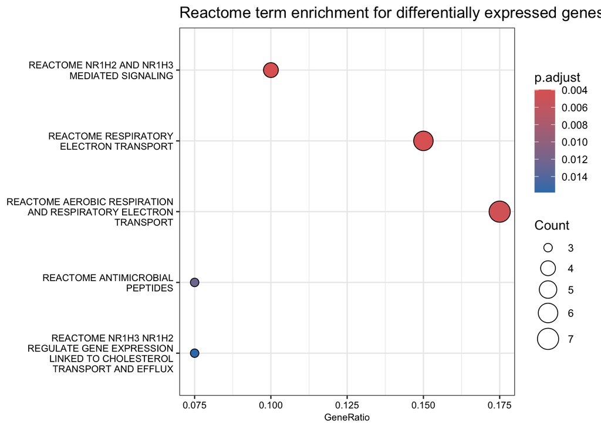

```r
Reactome_ora_results <- enricher(
  gene = deg_order$Ensembl, # A vector of your genes of interest
  pvalueCutoff = 0.05, # Can choose a FDR cutoff
  pAdjustMethod = "BH",
  universe = res_by_vital_status_df$Ensembl,# Method to be used for multiple testing correction
  # The pathway information should be a data frame with a term name or
  # identifier and the gene identifiers
  TERM2GENE = dplyr::select(
    mm_Reactome_df,
    gs_name,
    ensembl_gene
  )
)


enrich_plot_Reactome <- enrichplot::dotplot(Reactome_ora_results, showCategory=10,font.size=8,title="Reactome term enrichment for differentially expressed genes in survivors vs non-survivors",orderBy= "p.adjust", decreasing = FALSE)
enrich_plot_Reactome
```

Based on this analysis, the genes differentially expressed between those that died from Rectum adenocarcinoma vs those that did not priarily enrich for various transmembrane transporter genes as well immune response genes such as antimicrobial humoral response with additional involvement of ETC related genes.

In terms of pathways, NR1H2 and NR1H3 are Nuclear receptors that exhibits a ligand-dependent transcriptional activation activity and regulates cholesterol uptake through MYLIP-dependent ubiquitination of LDLR, VLDLR and LRP8; DLDLR and LRP8. These genes are also key regulators of macrophage function, controlling transcriptional programs involved in lipid homeostasis and inflammation.

Of note, macrophages control inflammation in the rectum via polarisation of M0 macrophages to M1 (pro-inflmmatory) and M2 (anti-inflammatory). They can be either pro-inflammatory, potentially inhibiting tumor growth, or anti-inflammatory, promoting tumor development and metastasis.Hence macrophage function via regulation of NR1H2 and NR1H3 receptor activity could be important to determining surival in Rectum adenocarcinoma.